# Filas

#### B) Estude a distribuição amostral do tamanho mediano da fila

##### Fixando casos de lambda

- Atendimento maior que chegadas 15 Atendimentos/h
- Atendimento igual à chegadas 10 Atendimentos/h
- Atendmento menor que chegadas 5 Atendimentos/h

```r
med_fila_igual <- replicate(10000, median(sim_fila(lambda_chegada = 10/60,
                                                lambda_atendimento = 10/60,
                                                tempo_expediente = 600)))

med_fila_maior <- replicate(10000, median(sim_fila(lambda_chegada = 10/60,
                                                lambda_atendimento = 15/60,
                                                tempo_expediente = 600)))

med_fila_menor <- replicate(10000, median(sim_fila(lambda_chegada = 10/60,
                                                lambda_atendimento = 5/60,
                                                tempo_expediente = 600)))
```

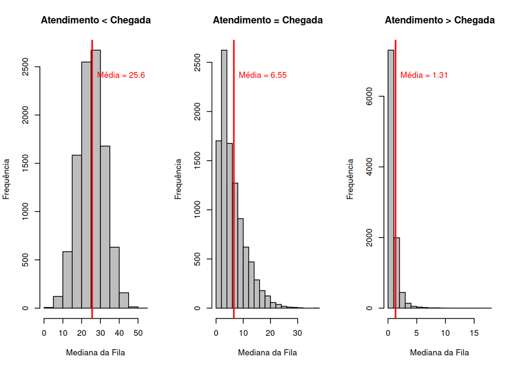

#### c) Estude a distribuição amostral do tamanho máximo da fila.

```r
max_fila_igual <- replicate(10000, max(sim_fila(lambda_chegada = 10/60,
                                                lambda_atendimento = 10/60,
                                                tempo_expediente = 600)))

max_fila_maior <- replicate(10000, max(sim_fila(lambda_chegada = 10/60,
                                                lambda_atendimento = 15/60,
                                                tempo_expediente = 600)))

max_fila_menor <- replicate(10000, max(sim_fila(lambda_chegada = 10/60,
                                                lambda_atendimento = 5/60,
                                                tempo_expediente = 600)))
```

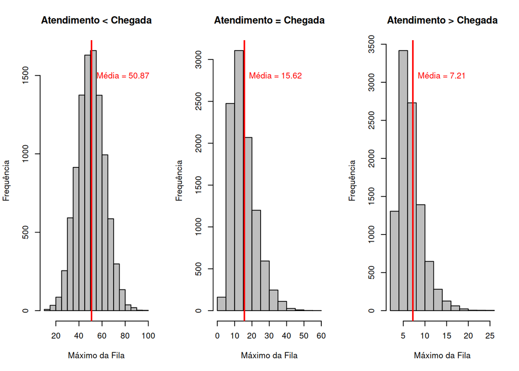

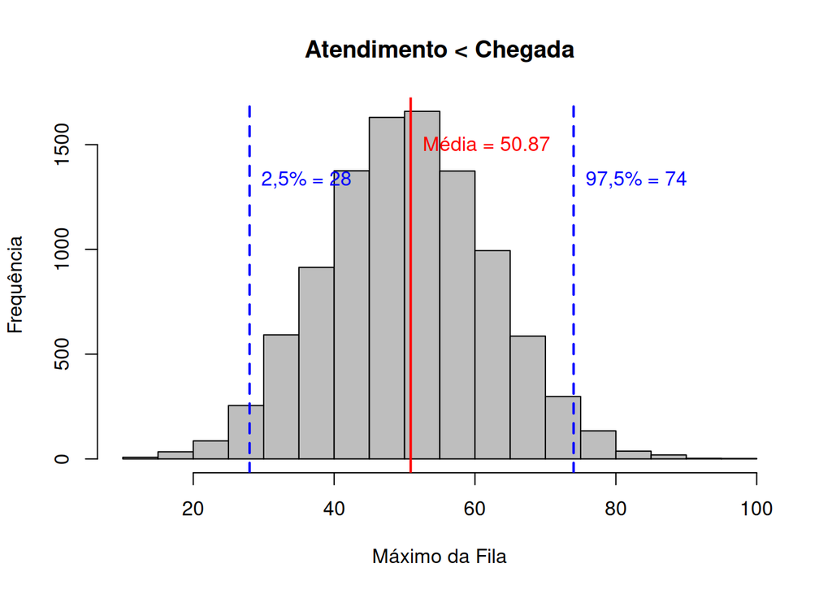

###### Supomos que se a fila chegar a 60 pessoas,o estabelecimento é interditado imediatamente, qual a chance disso acontecer sob essa parametrização ?

```r
(mean(max_fila_menor>60))
```

```
## [1] 0.2073
```

###### Qual deveria ser a taxa de atendimento para garantir que essa probabilidade seja abaixo dos 5% ??

```r
#6 Atendimentos/h
atend_6  <-replicate(10000, max(sim_fila(lambda_chegada = 10/60,
                                                lambda_atendimento = 6/60,
                                                tempo_expediente = 600)))

mean(atend_6>60)
```

```
## [1] 0.0642
```

```r
#7 Atendimentos/h


atend_7 <- replicate(10000, max(sim_fila(lambda_chegada = 10/60,
                                                lambda_atendimento = 7/60,
                                                tempo_expediente = 600)))

mean(atend_7>60)
```

```
## [1] 0.0132
```

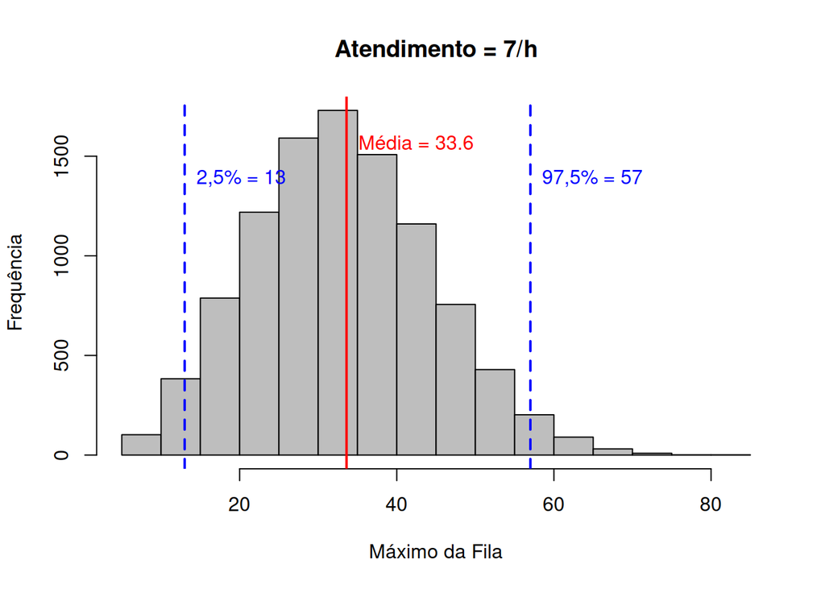

### Bônus

###### E se estivessimos lidando com um caso onde a taxa de chegada ou atendimento não é constante durante o expediente?

```r
sim_fila_2 <- function(lambda_chegada_1, lambda_atendimento_1, tempo_quebra,
                     lambda_chegada_2, lambda_atendimento_2, tempo_expediente) {

  tempo_total <- 0
  chegadas <- c()

  while (tempo_total < tempo_expediente) {
    if (tempo_total <= tempo_quebra) {
      tempo_proxima_chegada <- rexp(1, rate = lambda_chegada_1)
    } else {
      tempo_proxima_chegada <- rexp(1, rate = lambda_chegada_2)
    }
    tempo_total <- tempo_total + tempo_proxima_chegada
    if (tempo_total <= tempo_expediente) {
      chegadas <- c(chegadas, tempo_total)
    }
  }

  Total_chegadas <- length(chegadas)
  tempo_atendimento <- numeric(Total_chegadas)

  for (i in 1:Total_chegadas) {
    if (chegadas[i] <= tempo_quebra) {
      tempo_atendimento[i] <- rexp(1, rate = lambda_atendimento_1)
    } else {
      tempo_atendimento[i] <- rexp(1, rate = lambda_atendimento_2)
    }
  }

  inicio_atendimento <- numeric(Total_chegadas)
  fim_atendimento <- numeric(Total_chegadas)
  fila_atual <- numeric(Total_chegadas)

  inicio_atendimento[1] <- chegadas[1]
  fim_atendimento[1] <- inicio_atendimento[1] + tempo_atendimento[1]
  fila_atual[1] <- 0

  for (i in 2:Total_chegadas) {
    atendimentos_feitos <- sum(fim_atendimento <= chegadas[i] & fim_atendimento > 0)
    fila_atual[i] <- (i - 1) - atendimentos_feitos
    inicio_atendimento[i] <- max(max(fim_atendimento), chegadas[i])
    fim_atendimento[i] <- inicio_atendimento[i] + tempo_atendimento[i]
  }

  return(fila_atual)
}
```

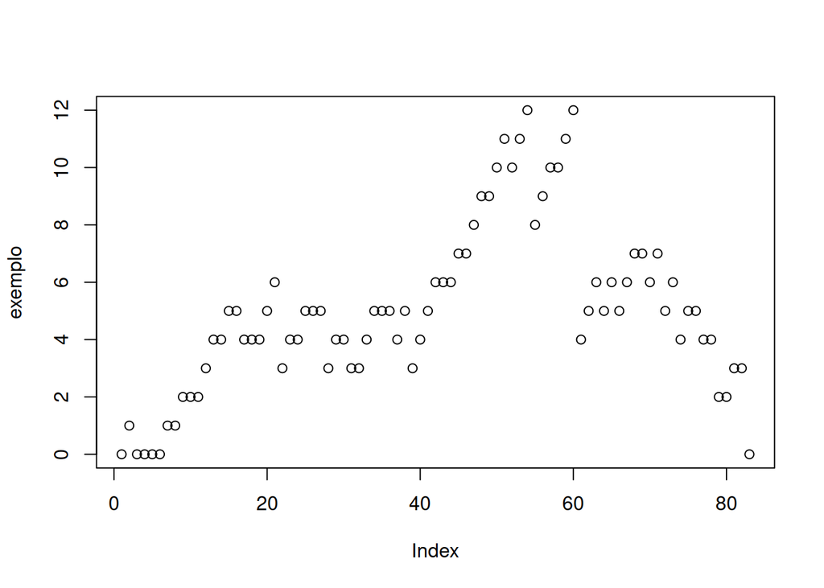

```r
exemplo <- sim_fila_2(lambda_chegada_1 = 10/60,
           lambda_atendimento_1 = 8/60,
           tempo_quebra = 300,
           lambda_chegada_2 = 5/60,
           lambda_atendimento_2 = 7/60,
           tempo_expediente = 600)

plot(exemplo)
```

### Obrigado :)